# Exercises: Clustering

Eva Freyhult, Mun-Gwan Hong

2022-09-15

#### Exercise 1

Using Edgar Anderson’s iris data, we will investigate K-means clustering. The data is stored in `iris` in R. Here we focus on `Sepal.Width` and `Petal.Width`.

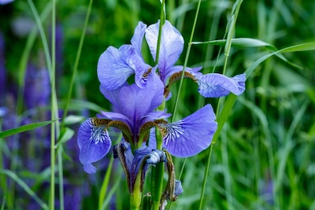

1. Examine the contents and data types of the data set *iris*.
2. Try to find three clusters in the data of sepal and petal widths using a k-means algorithm. You can use the function `kmeans` in R. It allows to choose an algorithm with the argument `algorithm` (e.g. `algorithm = "Forgy"`).
3. Plot the data and color by cluster ID
4. Repeat the same analysis a few times. Do you get the same clusters all the time? Use `table` to check it allowing different cluster numbers.
5. Try the argument `nstart` out and compare how stable two runs are. By setting the argument to 4, the algorithm will automatically try four different (random) starting points.
6. Try different values for $k$, run the k-means algorithm and collect the WSS (`tot.withinss`). Plot WSS vs $k$. The WSS is always decreasing as $k$ increases, but the curve can still give you a hint of which $k$ to choose. The Elbow method for selecting $k$ is to look at this curve and choose the $k$ that you find at the bend of the curve, at the ‘elbow’. Which $k$ would you pick based on this?
7. Compute the Silhouette width of the first object (or observation) when $k$ is 2.
8. (Optional) Compute average Silhouette width of all objects adjusting $k$ from 2 to 10 and choose optimal $k$. Euclidean distance can be computed by `dist`. Check the help of the function using `?dist`.
9. (Optional) Try `fviz_nbclust` of the R-package `factoextra` and choose optimal $k$ based on average Silhouette width.

#### Exercise 2

The NCI60 data set consists of gene expression values for 6830 genes for 64 cell lines. Using this data set, we investigate a few hierarchical clustering distances and linkage methods. The data can be downloaded in R using the following command

```
nci_data <- read.table(
  url("https://web.stanford.edu/~hastie/ElemStatLearn/datasets/nci.data.csv"),
  sep = ",",
  row.names = 1,
  header = TRUE
)
nci_label <- scan(
  url("https://web.stanford.edu/~hastie/ElemStatLearn/datasets/nci.label.txt"),
  what = ""
)
```

1. What is the size of the data matrix? Do every column represent a gene or a cell line?
2. Compute the Euclidean distance **between cell lines**. This can be accomplished using the function `dist`. Read the help text `?dist`. This function computes the distance between rows of the input data matrix. If the rows represent cell lines, you can run `dist(nci_data)`. But, if your cell lines are represented by columns, you need to transpose the data matrix first `t(nci_data)`.
3. Cluster the cell lines using complete linkage hierarchical clustering, use the function `hclust`.
4. Plot the dendrogram of the clustering result (The help for `hclust` includes the function for the plot)
   - Try changing the labels to something more informative using `nci_label`.
   - Investigate the argument `hang`, what happens if you set it to -1?
5. Try the linkage methods “single”, “average” and “ward.D” in addition to “complete”. Compare the results. Which method is ‘best’?

Pick the tree resulting from the method you think is ‘best’. How many clusters are there?

You can cut the tree on any level to get between 1 and 64 clusters. The function `cutree` either on a specific height (dissimilarity) or to get a specific number of clusters.